[figure not shown]

# Equations of Electrodynamics: From Maxwell to Helmholtz

### This talk **focuses** on

#### Deriving Helmholtz from Maxwell

#### Numerical/Analytical Solutions of Deterministic Helmholtz

#### Numercial Methods for Stochastic Helmholtz

#### Rates of Convergence

##### Maxwell's system in differential form:

[output not shown]

##### Definitions:

| Symbol | Meaning | SI unit of measure |
| --- | --- | --- |
| $$\vect{E}$$ | electric field | $$V/m$$ |
| $$\vect{P}$$ | electric polarization | $$N/ (Vm)$$ |
| $$\vect{D}$$ | electric displacement | $$N/(Vm)$$ |
| $$\vect{B}$$ | magnetic field | $$V s/m^2$$ |
| $$\vect{M}$$ | magnetization | $$A/m$$ |
| $$\vect{H}$$ | magnetic displacement | $$A/m$$ |
| $$\vect{J}_f$$ | current density | $$C/(s m^2)$$ |
| $$\vect{K}_f$$ | current surface density | $$C/ s m$$ |
| $$\rho_f$$ | charge density | $$C/ m^3$$ |
| $$\sigma_f$$ | surface charge density | $$C/ m^2$$ |
| $\epsilon_0 \approx 8.8 \times 10^{-12}$ | permitting of free space | $$C^2/(Nm^2)$$ |
| $$\mu_0 \approx 4\pi \times 10^{-7}$$ | permeability of free space | $$V s / (A m) $$ |
| $$c \approx 2.9 \times 10^{-8}$$ | speed of light in vac | $$m/s$$ |

##### Using the Constitutive Relations and taking **dot** products...

\begin{equation} \vect{E} \cdot \left(\nabla \times \frac{1}{\mu_0} \vect{B}\right) - \frac{1}{\mu_0} \vect{B} \cdot \left(\nabla \times \vect{E}\right) = \vect{E} \cdot \left(\nabla \times \vect{M}\right) + \vect{E} \cdot \vect{J}_f + \vect{E} \cdot \pder{\epsilon_0 \vect{E}}{t} + \vect{E} \cdot\pder{\vect{P}}{t} + \frac{1}{\mu_0} \vect{B} \pder{\vect{B}}{t} \end{equation}

##### or

\begin{equation} \pder{}{t}\left(\frac{\epsilon_0}{2} \vect{E} \cdot \vect{E} + \frac{1}{2\mu_0}\vect{B}\cdot\vect{B}\right) = -\nabla \cdot \left(\vect{E} \times \frac{1}{\mu_0} \vect{B}\right) - \vect{E} \cdot \left( \vect{J}_f + \pder{\vect{P}}{t} + \left(\nabla \times \vect{M}\right)\right) \end{equation}

##### produces conservation (energy density) equation!

##### Using the Constitutive Relations and taking **cross** products...

\begin{equation} \begin{split} \epsilon_0 \nabla \cdot \vect{E} +\nabla \cdot \vect{P} &= \rho_f \\ \nabla \times \nabla \times \vect{E} & = - \mu_0\pder{\vect{J}_f}{t} - \mu_0\pder{\left(\nabla \times \vect{M}\right)}{t} - \mu_0 \epsilon_0 \ppder{\vect{E}}{t} -\mu_0\ppder{\vect{P}}{t}\\ \nabla \cdot \vect{B} &= 0 \\ \nabla \times \nabla \times \vect{B} &= \mu_0\nabla \times \nabla \times \vect{M} + \mu_0 \nabla \times \vect{J}_f - \mu_0 \epsilon\ppder{\vect{B}}{t} +\mu_0 \pder{\left(\nabla \times\vect{P}\right)}{t} \end{split} \end{equation}

##### and using $\nabla \times \nabla \times\vect{A} = -\nabla^2\vect{A} + \nabla (\nabla \cdot \vect{A})$...

\begin{equation} \begin{split} \nabla \cdot \vect{E} &= \frac{\rho_f}{\epsilon_0} - \frac{1}{\epsilon_0} \nabla \cdot \vect{P} \\ \nabla^2 \vect{E} - \mu_0 \epsilon_0 \ppder{\vect{E}}{t} &= \mu_0\pder{\vect{J}_f}{t} + \mu_0\pder{\left(\nabla \times \vect{M}\right)}{t} + \frac{\nabla \rho_f}{\epsilon_0} - \frac{1}{\epsilon_0} \nabla \left(\nabla \cdot \vect{P} \right) + \mu_0\ppder{\vect{P}}{t}\\ \nabla \cdot \vect{B} &= 0 \\ \nabla^2\vect{B} - \mu_0 \epsilon_0 \ppder{\vect{B}}{t} &= -\mu_0\nabla \times \nabla \times \vect{M} - \mu_0 \nabla \times \vect{J}_f - \mu_0 \pder{\left(\nabla \times\vect{P}\right)}{t} \end{split} \end{equation}

##### produces wave equations!

##### Lets make some assumptions...

- Non-magnetic medium with no free charge: $ \rho_f = 0$, $\vect{J}_f = \vect{0}$, $\vect{M} = \vect{0}$

\begin{equation} \begin{split} \nabla \cdot \vect{E} &= \xcancel{\frac{\rho_f}{\epsilon_0}} - \frac{1}{\epsilon_0} \nabla \cdot \vect{P} \\ \nabla^2 \vect{E} - \mu_0 \epsilon_0 \ppder{\vect{E}}{t} &= \xcancel{\mu_0\pder{\vect{J}_f}{t}} + \xcancel{\mu_0\pder{\left(\nabla \times \vect{M}\right)}{t}} + \xcancel{\frac{\nabla \rho_f}{\epsilon_0}} - \frac{1}{\epsilon_0} \nabla \left(\nabla \cdot \vect{P} \right) + \mu_0\ppder{\vect{P}}{t}\\ \nabla \cdot \vect{B} &= 0 \\ \nabla^2\vect{B} - \mu_0 \epsilon_0 \ppder{\vect{B}}{t} &= \xcancel{-\mu_0 \nabla \times \nabla \times \vect{M}} - \xcancel{\mu_0 \nabla \times \vect{J}_f} - \mu_0 \pder{\left(\nabla \times\vect{P}\right)}{t} \end{split} \end{equation}

##### Lets make some assumptions...

- Non-magnetic medium with no free charge: $ \rho_f = 0$, $\vect{J}_f = \vect{0}$, $\vect{M} = \vect{0}$
- Instantious and isotropic polarization: $\vect{P}(\vect{E}) = \epsilon_0 \chi(\vect{r},t) \vect{E}$

  \begin{equation} \begin{split} \nabla \cdot \vect{E} &= -\chi\nabla \cdot \vect{E} - \vect{ \nabla\chi} \cdot \vect{E} \\ \nabla^2 \vect{E} - \frac{1}{c^2} \ppder{\vect{E}}{t} &= - \nabla \left(\nabla \cdot \chi \vect{E} \right) + \frac{1}{c^2} \ppder{ \chi \vect{E}}{t}\\ \nabla \cdot \vect{B} &= 0 \\ \nabla^2\vect{B} - \frac{1}{c^2}\ppder{\vect{B}}{t} &= -\frac{1}{c^2} \pder{\left(\nabla \times \chi \vect{E}\right)}{t} \end{split} \end{equation}

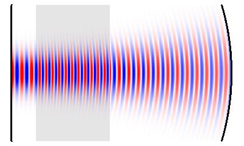

```python
Image('http://www.rp-photonics.com/img/resonator_mode_2.png')
#Image('images/resonator_mode_2.png')
```